# Part A: Data Cleaning & Exploratory Analysis

```python
import pandas as pd

print("Original shape:", data.shape)  # Expected output: (864863, 74)

selected_columns = ['T_degC', 'Salnty', 'STheta']   #remove all NaN and NA values
data_subset = data[selected_columns].dropna()

# Step 4: Verifying the shape (812174, 3)
print("Shape after removing NaN values:", data_subset.shape)  # Expected output: (812174, 3)

# Step 5: Displaying first few rows
print(data_subset.head())
```

```
Original shape: (864863, 74)
Shape after removing NaN values: (812174, 3)
   T_degC  Salnty  STheta
0   10.50  33.440  25.649
1   10.46  33.440  25.656
2   10.46  33.437  25.654
3   10.45  33.420  25.643
4   10.45  33.421  25.643
```

```python
#3. Build the following plots using matplotlib:
```

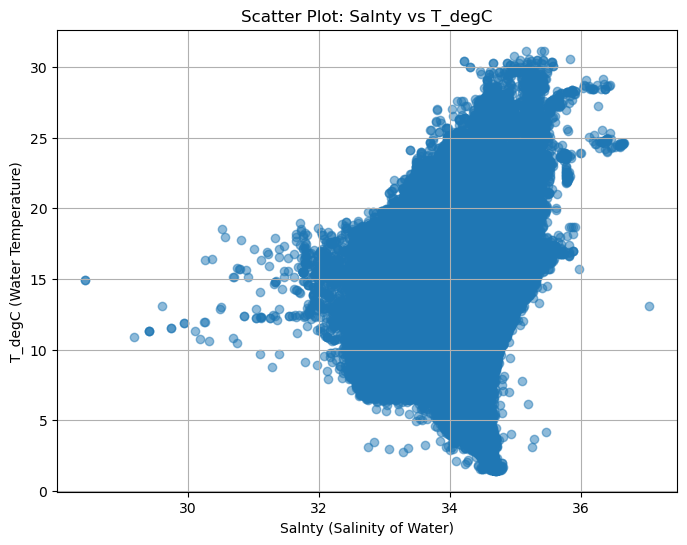

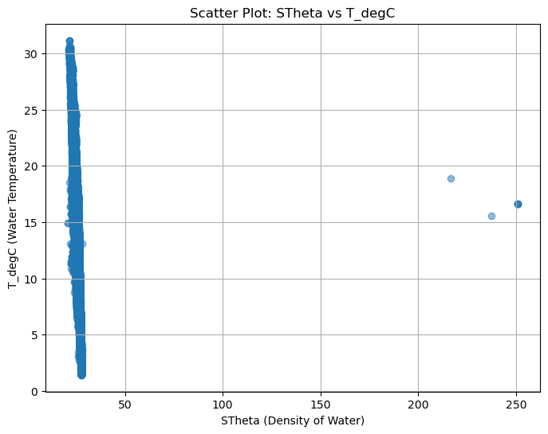

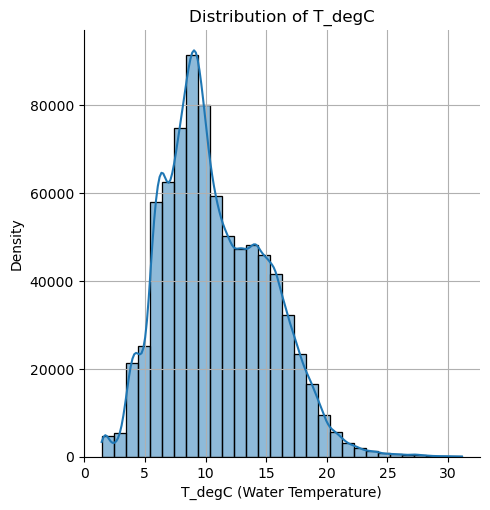

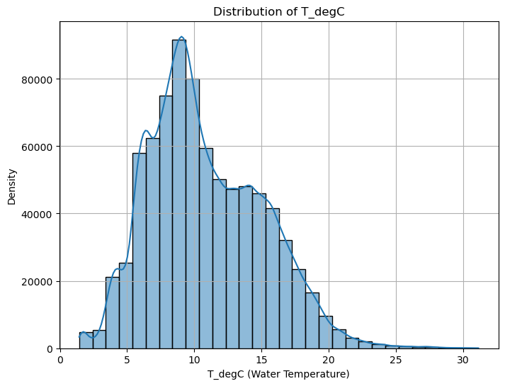

```python
import pandas as pd
import matplotlib.pyplot as plt
import seaborn as sns

# Scatter plot: Salnty vs T_degC

plt.figure(figsize=(8, 6))
plt.scatter(data_subset['Salnty'], data_subset['T_degC'], alpha=0.5)
plt.title('Scatter Plot: Salnty vs T_degC')
plt.xlabel('Salnty (Salinity of Water)')
plt.ylabel('T_degC (Water Temperature)')
plt.grid(True)
plt.show()

# Scatter plot: STheta vs T_degC

plt.figure(figsize=(8, 6))
plt.scatter(data_subset['STheta'], data_subset['T_degC'], alpha=0.5)
plt.title('Scatter Plot: STheta vs T_degC')
plt.xlabel('STheta (Density of Water)')
plt.ylabel('T_degC (Water Temperature)')
plt.grid(True)
plt.show()

# Distribution plot of T_degC using seaborn displot

plt.figure(figsize=(8, 6))
sns.displot(data_subset['T_degC'], bins=30, kde=True)
plt.title('Distribution of T_degC')
plt.xlabel('T_degC (Water Temperature)')
plt.ylabel('Density')
plt.grid(True)
plt.show()

# Distribution plot of T_degC
plt.figure(figsize=(8, 6))
sns.histplot(data_subset['T_degC'], bins=30, kde=True)
plt.title('Distribution of T_degC')
plt.xlabel('T_degC (Water Temperature)')
plt.ylabel('Density')
plt.grid(True)
plt.show()
```

#5. Remove obvious outliers from step 3b

```
Shape for clean data: (812168, 3)
```

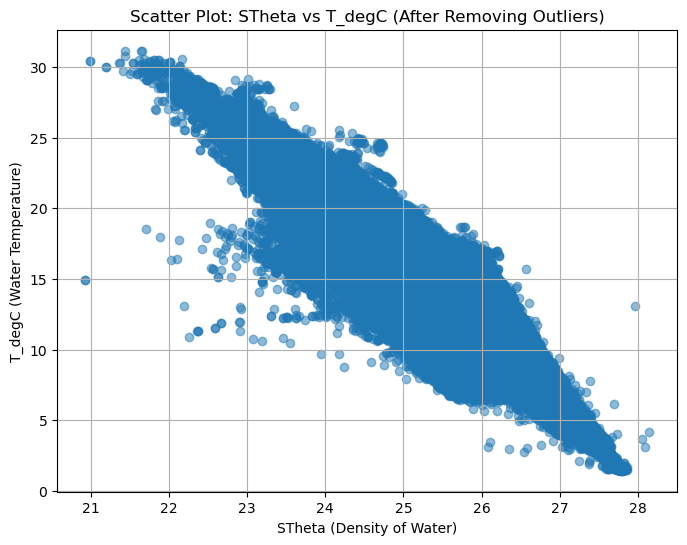

```python
# Remove outliers based on extreme STheta values
threshold = 30  # Adjust threshold as needed
clean_data_subset = data_subset[data_subset['STheta'] < threshold]

# Verify the shape of clean data
print("Shape for clean data:", clean_data_subset.shape)  # Expected output: (812168, 3)

# Scatter plot: STheta vs T_degC (after removing outliers)
plt.figure(figsize=(8, 6))
plt.scatter(clean_data_subset['STheta'], clean_data_subset['T_degC'], alpha=0.5)
plt.title('Scatter Plot: STheta vs T_degC (After Removing Outliers)')
plt.xlabel('STheta (Density of Water)')
plt.ylabel('T_degC (Water Temperature)')
plt.grid(True)
plt.show()
```

# Part B: Train & Test Split:

```python
import pandas as pd
from sklearn.model_selection import train_test_split

# Limit the dataset to the required columns and remove NaN values
data_subset = data[['T_degC', 'Salnty', 'STheta']].dropna()

# Define features (X) and target variable (y)
X = data_subset[['Salnty', 'STheta']]
y = data_subset['T_degC']

# Split the data into training and testing sets
X_train, X_test, y_train, y_test = train_test_split(X, y, test_size=0.2, random_state=42)

# Display the shapes of the training and testing sets
print("X_train shape:", X_train.shape)
print("X_test shape:", X_test.shape)
print("y_train shape:", y_train.shape)
print("y_test shape:", y_test.shape)
```

```
X_train shape: (649739, 2)
X_test shape: (162435, 2)
y_train shape: (649739,)
y_test shape: (162435,)
```

# Part C: Linear Regression Using Normal Equation - Coded In Python

```
Coefficients: [92.38485716 -0.21113424 -2.8812375 ]
Mean Squared Error: 4.520259592995444
R-squared: 0.7454276072299812
Explained Variance: 0.7454276374308609
```

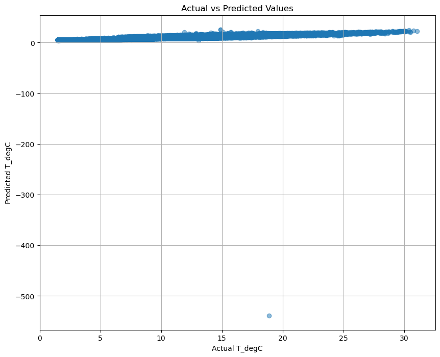

```python
import numpy as np
from sklearn.metrics import mean_squared_error, r2_score, explained_variance_score
import matplotlib.pyplot as plt

# Add intercept value of 1 for every observation in X_train and X_test
X_train_with_intercept = np.column_stack((np.ones(len(X_train)), X_train))
X_test_with_intercept = np.column_stack((np.ones(len(X_test)), X_test))

# Build the Normal Equation
theta = np.linalg.inv(X_train_with_intercept.T.dot(X_train_with_intercept)).dot(X_train_with_intercept.T).dot(y_train)

# Print out the coefficients
print("Coefficients:", theta)

# Predict T_degC for the test data
y_pred = X_test_with_intercept.dot(theta)

# Calculate mean squared error
mse = mean_squared_error(y_test, y_pred)
print("Mean Squared Error:", mse)

# Calculate R-squared
r2 = r2_score(y_test, y_pred)
print("R-squared:", r2)

# Calculate explained variance
explained_variance = explained_variance_score(y_test, y_pred)
print("Explained Variance:", explained_variance)

# Create scatterplot of actual versus predicted values
plt.figure(figsize=(10, 8))
plt.scatter(y_test, y_pred, alpha=0.5)
plt.title('Actual vs Predicted Values')
plt.xlabel('Actual T_degC')
plt.ylabel('Predicted T_degC')
plt.grid(True)
plt.show()
```

# Part D: Using sklearn API

```
Intercept: 92.38485716392799
Coefficients: [-0.21113424 -2.8812375 ]
Mean Squared Error (sklearn): 4.520259592999708
R-squared (sklearn): 0.7454276072297411
Explained Variance (sklearn): 0.7454276374306205
```

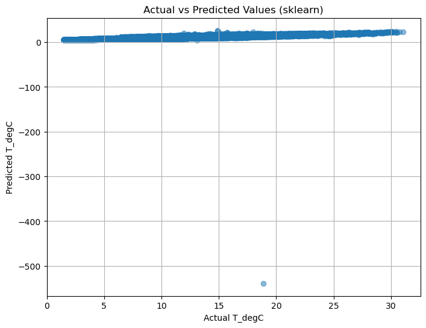

```python
from sklearn.linear_model import LinearRegression
from sklearn.metrics import mean_squared_error, r2_score, explained_variance_score
import matplotlib.pyplot as plt

# Create an instance of LinearRegression
lin_reg = LinearRegression()

# Fit lin_reg using X_train & y_train
lin_reg.fit(X_train, y_train)

# Print out the coefficients
print("Intercept:", lin_reg.intercept_)
print("Coefficients:", lin_reg.coef_)

# Predict T_degC for the test data using the fitted values
y_pred_sklearn = lin_reg.predict(X_test)

# Calculate mean squared error
mse_sklearn = mean_squared_error(y_test, y_pred_sklearn)
print("Mean Squared Error (sklearn):", mse_sklearn)

# Calculate R-squared
r2_sklearn = r2_score(y_test, y_pred_sklearn)
print("R-squared (sklearn):", r2_sklearn)

# Calculate explained variance
explained_variance_sklearn = explained_variance_score(y_test, y_pred_sklearn)
print("Explained Variance (sklearn):", explained_variance_sklearn)

# Create scatterplot of actual versus predicted values
plt.figure(figsize=(8, 6))
plt.scatter(y_test, y_pred_sklearn, alpha=0.5)
plt.title('Actual vs Predicted Values (sklearn)')
plt.xlabel('Actual T_degC')
plt.ylabel('Predicted T_degC')
plt.grid(True)
plt.show()
```

# Part E: Conceptual Questions

# 1. Why is it important to have a test set? #Test set is important for evaluating the performance of a machine learning model. # Without test set, we would have no way of knowing the performance of the #model such as overfitting or undefitting .

# 2. If the normal equation always provides a solution, when would we not want to use it? # Ans: One limitation is scalibility as the data size grows , computational cost of computing the inverse of - # the feature matrix becomes impossible.

# 3. How might we improve the fit of our models from Part C & D? #Note: There are lots of possible answers to this section - just describe one in detail. # Ans : One way to improve the fit of our models from Part C & D is to use feature engineering. # For example, instead of creating using 'Salnty' and ' STheta' as separate features , we could- # use interaction terms to capture nonlinear relationships.

# 4. As we move further into Machine Learning, we will need to continually consider the bias-variance tradeoff. #Explain what bias is and what variance is in regards to the bias-variance tradeoff.

# If our model is too simple and has very few parameters then it may have high bias and low variance. # On the other hand if our model has large number of parameters then it’s going to have high variance and low bias. # So we need to find the right/good balance without overfitting and underfitting the data. # To build a good model, we need to find a good balance between bias and variance such that it minimizes the total error.

# 5. In a linear regression model, how might we reduce bias? #Ans : To reduce bias in a linear regression model, we can increase its complexity by adding more features, #including polynomial features, interaction terms, or performing feature engineering. These techniques enable the model #to capture more complex relationships between predictors and the target variable.

# 6. In a linear regression model, how might we reduce variance? #Ans: To reduce variance in a linear regression model, we can apply regularization techniques such as # Ridge regression or Lasso regression. These methods add a penalty term to the loss function, which helps # to limit the magnitude of the coefficients and prevent overfitting. Additionally, reducing the complexity # of the model by removing irrelevant features or using feature selection methods can also help reduce variance.